# Statistics with FPL | t-test

t-tests are used to test whether the means of two groups are significantly different from each other.

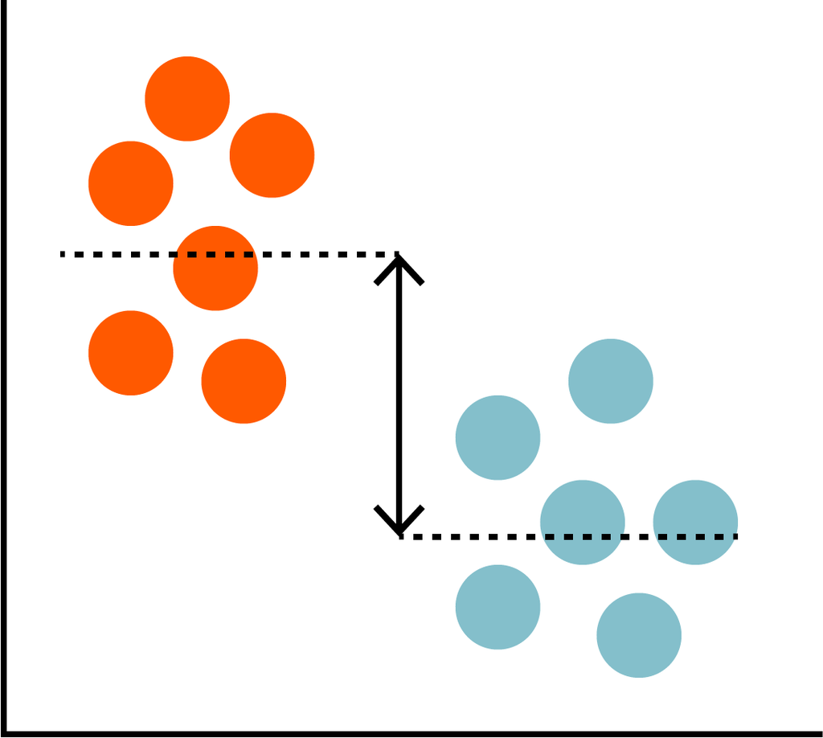

There are three main types of t-test:

- One-sample t-test: compare a sample mean to a reference mean value.
- Independent samples t-test: compare the means of two independent groups.
- Paired samples t-test: compare two means taken from the same group under different conditions.

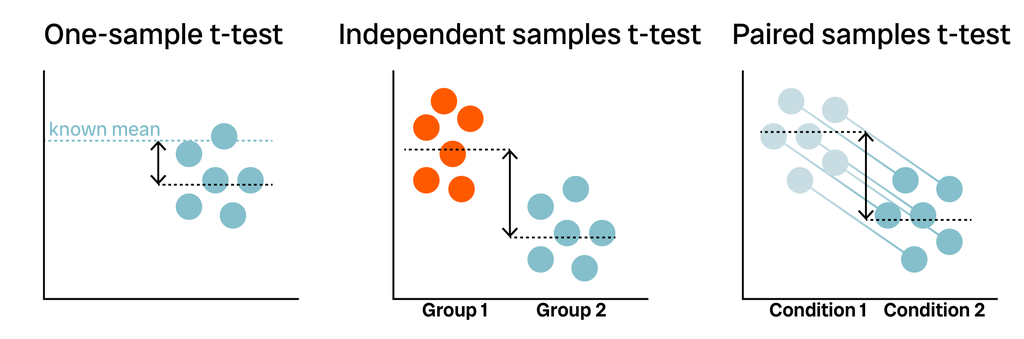

Using a t-test involves making some assumptions about the data:

- The means must be a metric such as age or height.
- The metric must be approximately normally distributed.

## 1. One-sample t-test: Do teams in the Premier League Have a Mean Team Size of 25?

If we had a hypothesis that ‘The mean team size in the Premier League is 25’, we could try and test if this is true using a one-sample t-test.

- The Null Hypothesis here is that the mean team size in the Premier League = 25.
- The Alternative Hypothesis is that the mean team size in the Premier League is different to 25.

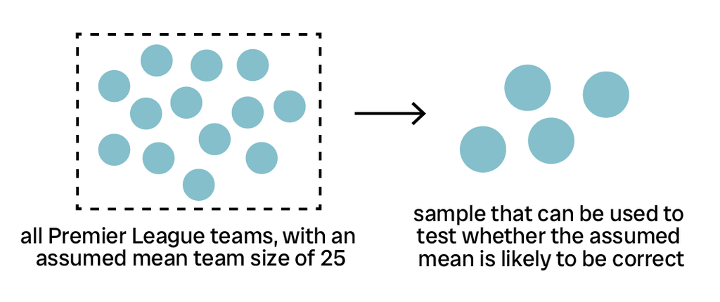

For this example we are going to pretend that we don’t have access to the entire dataset: we are only able to sample 10 teams from the dataset to test whether this hypothesis is true. This is because a one-sample t-test is designed to test the mean of a sample against a mean from a population that we cannot measure.

First, let’s load the packages we need and download the data from GW1.

```r
# Load packages
library(readr)
library(dplyr)
library(ggplot2)
library(cowplot)
library(geomtextpath)
library(lessR)
library(BSDA)
library(distributions3)
library(car)
set.seed(1)

# Data is from vaastav's repository
github <- 'https://raw.githubusercontent.com/vaastav/Fantasy-Premier-League/master/data/'

# We want details about GW1 from 2023-24
gw1 <- read_csv(url(paste0(github, "2023-24/gws/gw1.csv")))

# Get team size and sample 10 teams
teamSize <- gw1 %>% group_by(Team=team) %>% summarise(N=n()) %>% sample_n(10)

# Set output size for plots
knitr::opts_chunk$set(fig.width=5, fig.height=3.5)
```

To inspect the data we can plot the team sizes from our sample of 10 teams.

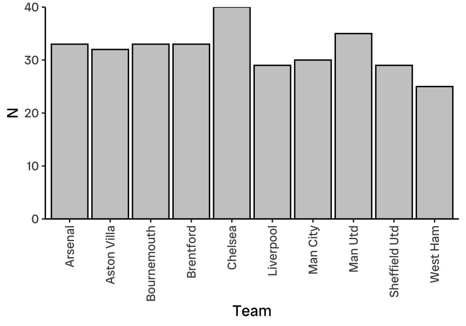

```r
# Set a theme to apply to all output graphs
theme <- theme_classic() + theme(text = element_text(size = 12, family='Radio Canada Big'))

# Use ggplot to input values for x and y axis
ggplot(teamSize, aes(x=Team, y=N)) +
  geom_col(fill='#cbcbcb', colour='black') +
  theme +
  theme(axis.text.x = element_text(angle = 90, vjust = 0.5, hjust=1)) +
  scale_y_continuous(expand=c(0,0))
```

We can also use a boxplot to see the quartiles of the team sizes from our sample of 10 teams.

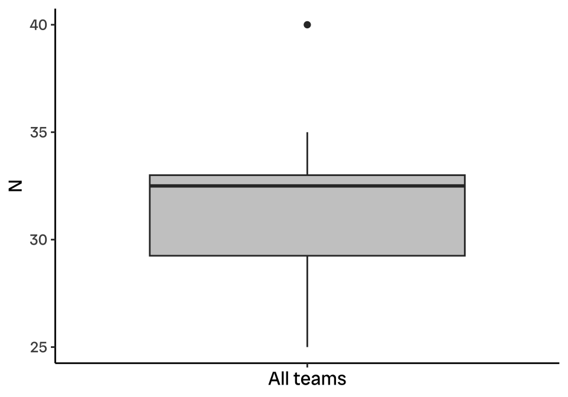

```r
# Copy dataframe, add a single variable to group all teams together, and turn into factor
teamSizeBox <- teamSize
teamSizeBox$`All teams` <- 'All teams'
teamSizeBox$`All teams` <- as.factor(teamSizeBox$`All teams`)

# Use ggplot to input values for x and y axis
ggplot(teamSizeBox, aes(y=N, x=`All teams`)) +
  geom_boxplot(fill='#cbcbcb') +
  theme +
  theme(axis.text.x = element_blank())
```

Now we need to check whether our data is normally distributed, as this is an assumption of the t-test. We can use a QQ plot to see if actual team sizes reflect theorectical sizes predicted from a normal distribution.

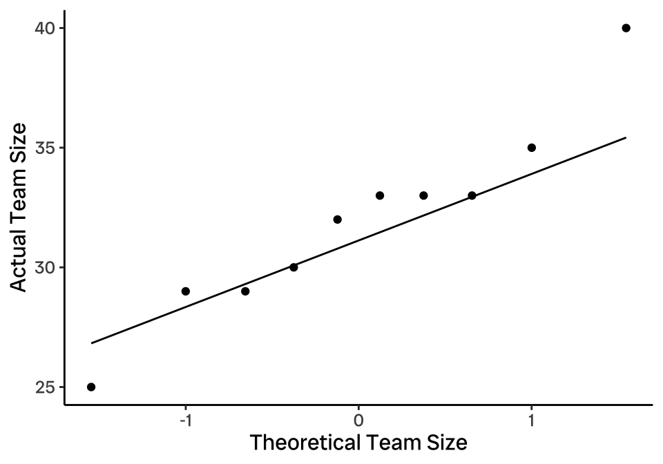

```r
# Does data follow normal distribution: QQ plot
ggplot(teamSize, aes(sample=N)) +
  geom_qq_line() +
  stat_qq() +
  theme_classic() +
  theme +
  labs(x='Theoretical Team Size', y='Actual Team Size')
```

From the QQ plot it appears that this data is normally distributed. We can also use a Shapiro-Wilk test to check that the data is normal.

```r
# Does data follow normal distribution: Shapiro-Wilks
shapiro.test(teamSize$N)
```

```
##
##  Shapiro-Wilk normality test
##
## data:  teamSize$N
## W = 0.95516, p-value = 0.7296
```

A non-significant result from the Shapiro-Wilks indicates normality, so we can use a t-test here.

To calculate the t-statistic we use this equation:

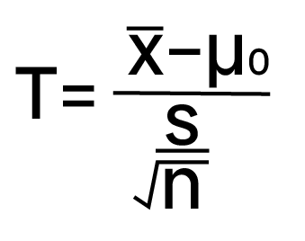

Where n = 10, μ0 = 25, x bar is the mean of our sample, and s is the standard deviaton of our sample.

```r
# Calculate the t-statistic
tStat <- (mean(teamSize$N) - 25) / (sd(teamSize$N) / sqrt(10))
tStat
```

```
## [1] 5.400817
```

The t-statistic is essentially a ratio of the difference between the estimated value and the assumed value, to the standard error of the estimated value, so more extreme values indicate an sample mean that is very different from the assumed mean.

We can see just how extreme our t-statistic is by estimating the probability of obtaining T=±5.4 or a more extreme value. This probability value is known as a p-value. If the probability of obtaining T=±5.4 or a more extreme value is below 5%, we can reject our null hypothesis that the sample mean = 25.

First we need to identify the appropriate t-distribution. Our sample has 10 teams, so we choose the distribution with 10-1 = 9 degrees of freedom. Let’s plot the corresponding distribution:

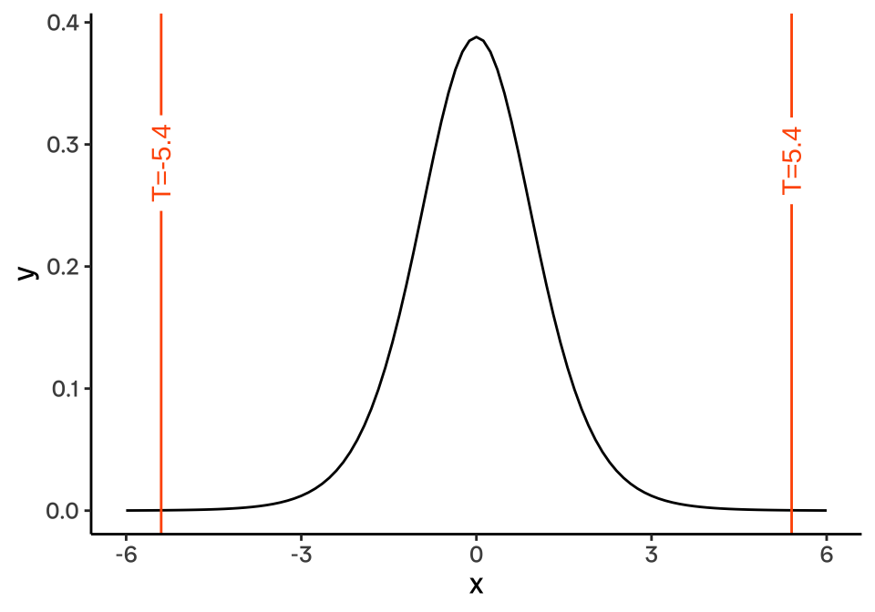

```r
# T-distribution plot
ggplot(data.frame(x = c(-6, 6)), aes(x = x)) +
  stat_function(fun = dt, args = list(df = 9)) +
  theme +
  geom_textvline(label = c('T=-5.4', 'T=5.4'), hjust=0.75, xintercept=c(-5.4,5.4), colour='#ff5900')
```

Now we can obtain the p-value from the t-statistic. This is equivalent to getting the area under the curve from x = -Inf to -5.4 and 5.4 to Inf.

```r
# Calculate p-value
Tdistribution <- StudentsT(df = 10-1)
(1 - cdf(Tdistribution, tStat) + cdf(Tdistribution, -tStat))*100
```

```
## [1] 0.04325441
```

The p-value corresponding to a t-statistic of 5.4 is 0.043%. This is below 5% so we can reject the null hypothesis that the mean Premier League team size is 25.

Another step we can take is to calculate the 95% confidence interval: a 95% confidence interval is an range of values 2SD either side of the estimated mean, and the chance the true mean of the population lies within this interval is 95%.

To calculate the 95% confidence inverval, we get the t-statistic ±2SD either side of the t-statistic we calculated earlier (5.4).

```r
# 95% confidence interval around the sample mean
mean(teamSize$N) + quantile(Tdistribution, 0.05 / 2) * sd(teamSize$N) / sqrt(length(teamSize$N))
```

```
## [1] 29.0099
```

```r
mean(teamSize$N) - quantile(Tdistribution, 0.05 / 2) * sd(teamSize$N) / sqrt(length(teamSize$N))
```

```
## [1] 34.7901
```

Another way to do this is to use the t.test() function, and set the mean we are testing as 25. The test is two sided as we don’t know if the true mean is greater or smaller than 25.

```r
t.test(teamSize$N, mu = 25, alternative = "two.sided")
```

```
##
##  One Sample t-test
##
## data:  teamSize$N
## t = 5.4008, df = 9, p-value = 0.0004325
## alternative hypothesis: true mean is not equal to 25
## 95 percent confidence interval:
##  29.0099 34.7901
## sample estimates:
## mean of x
##      31.9
```

## 2. Independent Samples t-test: Did Arsenal Have a Higher Mean xG Than Aston Villa?

Let’s say we want to see if Arsenal had a significantly higher xG per match in 2023-24 than Aston Villa. We can use an independent two-samples t-test to test whether this might be true.

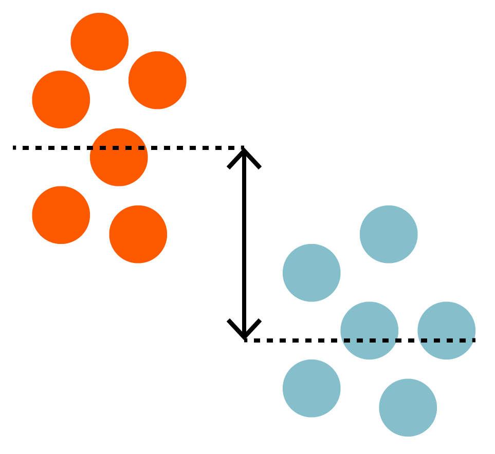

- The Null Hypothesis here is that the mean xG for Arsenal and Aston Villa are the same.
- The Alternative Hypothesis is that the mean xG for Arsenal is bigger than the mean xG for Aston Villa.

First we need to get data from every gameweek of 2023-24.

```r
# We need to get player details from every week
gws <- read_csv(url(paste0(github, "2023-24/gws/gw1.csv")))
for (i in 2:37){
  gw <- read_csv(url(paste0(github, "2023-24/gws/gw", i, ".csv")))
  gws <- rbind(gws, gw)
}
```

Then we can get the xG for each week for Arsenal and Aston Villa.

```r
# Get total xG from all Arsenal and Aston Villa players for each week
xGArsenal <- gws %>% filter(team=='Arsenal') %>% group_by(round) %>% summarise(xG=sum(expected_goals))
xGArsenal$Team <- 'Arsenal'
xGAstonVilla <- gws %>% filter(team=='Aston Villa') %>% group_by(round) %>% summarise(xG=sum(expected_goals))
xGAstonVilla$Team <- 'Aston Villa'

# Bind dataframes
xGmerge <- rbind(xGArsenal, xGAstonVilla)
```

Let’s plot these to visualise the distribution of xG for each team.

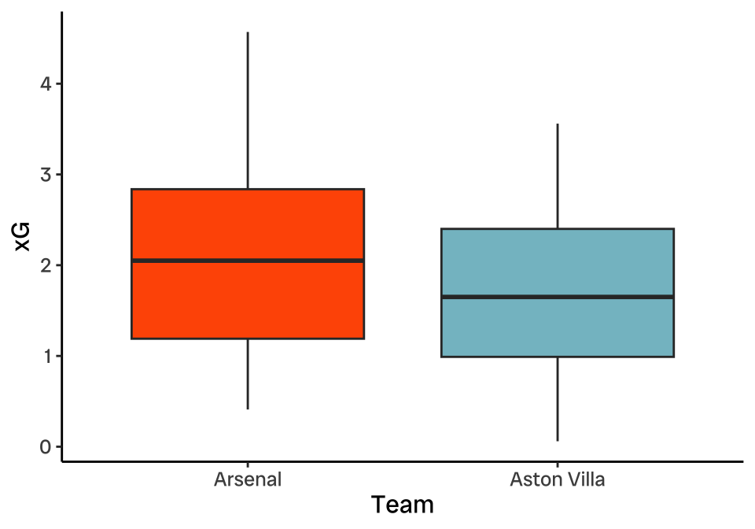

```r
# Use ggplot to input values for x and y axis
ggplot(xGmerge, aes(y=xG, x=Team)) +
  geom_boxplot(fill=c('#ff5900', '#84bfcb')) +
  theme
```

Now we can plot a QQ plot and perform two Shapiro-Wilk tests to check that the data for each team is normally distributed.

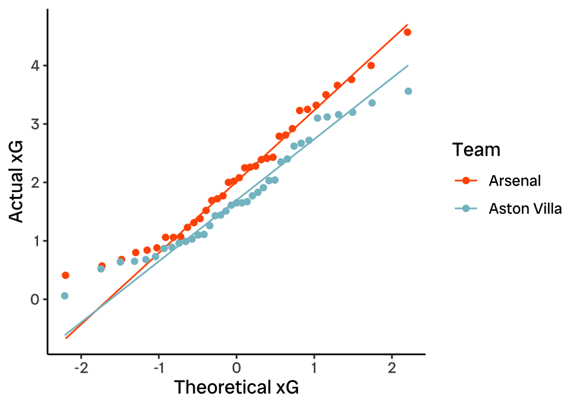

```r
# Does data follow normal distribution: QQ plot
ggplot(xGmerge, aes(sample=(xG), colour=Team)) +
  geom_qq_line() +
  stat_qq() +
  theme_classic() +
  theme +
  labs(x='Theoretical xG', y='Actual xG') +
  scale_colour_manual(values=c('#ff5900', '#84bfcb'))
```

```r
# Does data follow normal distribution: Shapiro-Wilk
shapiro.test(xGAstonVilla$xG)
```

```
##
##  Shapiro-Wilk normality test
##
## data:  xGAstonVilla$xG
## W = 0.95494, p-value = 0.1392
```

```r
shapiro.test(xGArsenal$xG)
```

```
##
##  Shapiro-Wilk normality test
##
## data:  xGArsenal$xG
## W = 0.96637, p-value = 0.3349
```

We can conclude from the QQ plot and Shapiro-Wilk tests that the xG data is approximately normally distributed for both teams.

Something else we need to check is whether our two groups have approximately equal variance. This can be tested using Levene’s test or the F-test.

```r
# Does data for each team have equal variance: Levene's test
xGmerge$Team <- as.factor(xGmerge$Team)
leveneTest(xG ~ Team, xGmerge)
```

```
## Levene's Test for Homogeneity of Variance (center = median)
##       Df F value Pr(>F)
## group  1    1.07 0.3044
##       71
```

```r
# F-test
var.test(xG ~ Team, xGmerge)
```

```
##
##  F test to compare two variances
##
## data:  xG by Team
## F = 1.365, num df = 35, denom df = 36, p-value = 0.3572
## alternative hypothesis: true ratio of variances is not equal to 1
## 95 percent confidence interval:
##  0.7005094 2.6680956
## sample estimates:
## ratio of variances
##           1.364954
```

Levene’s test and the F-test both return a non-significant result, meaning we cannot reject the null hypothesis that the variances are equal. This means we can use an independent two-samples t-test with equal variance on our data. If the variance was unequal, we could use Welch’s t-test, which accounts for the variance of both groups.

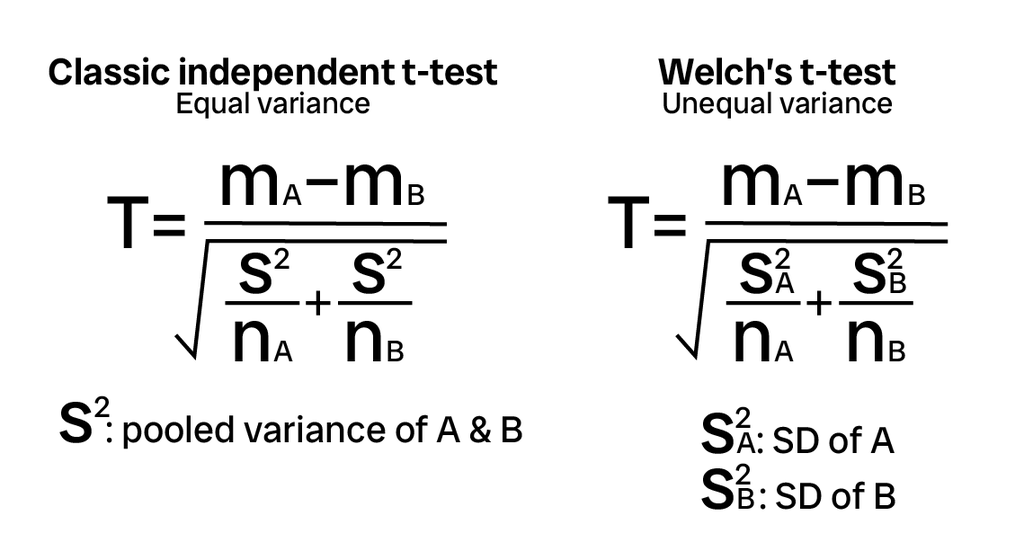

Before performing the t-test we need to calculate the pooled variance of the two groups, using this equation:

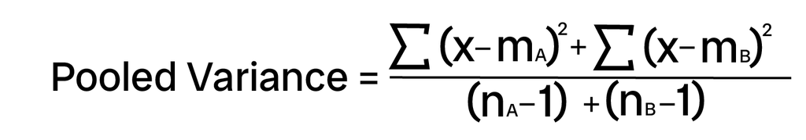

Now we can input our values into the classic independent t-test equation to get the t-statistic.

```r
# Get the sum of differences between each value and the mean for Arsenal and Aston Villa
sumArsenal <- 0
for (i in 1:nrow(xGArsenal)){sumArsenal <- sumArsenal + ((xGArsenal$xG[i]-mean(xGArsenal$xG))**2)}

sumAstonVilla <- 0
for (i in 1:nrow(xGAstonVilla)){sumAstonVilla <- sumAstonVilla + ((xGAstonVilla$xG[i]-mean(xGAstonVilla$xG))**2)}

# Calculate pooled variance
var <- (sumArsenal + sumAstonVilla)/(nrow(xGAstonVilla)-1+nrow(xGArsenal)-1)

# Calculate the t-tstatistic
tStat <- (mean(xGArsenal$xG) - mean(xGAstonVilla$xG)) / sqrt((var/nrow(xGArsenal)) + (var/nrow(xGAstonVilla)))
tStat
```

```
## [1] 1.579216
```

We can see how extreme a t-statistic of 1.58 is by estimating the probability of obtaining T=1.58 or a more extreme value. Our test has 36+37-2 = 71 degrees of freedom: we can plot the corresponding t-distribution to visualise the relationship between the t-statistic and the p-value.

```r
# Calculate p-value
Tdistribution <- StudentsT(df = 71)
(1 - cdf(Tdistribution, tStat))*100
```

```
## [1] 5.936586
```

[figure not shown]

```r
# T-distribution plot
ggplot(data.frame(x = c(-6, 6)), aes(x = x)) +
  stat_function(fun = dt, args = list(df = 71), xlim=c(1.5792, 5),
              geom = "area", aes(fill='0.0594%')) +
  theme +
  labs(fill=NULL) +
  stat_function(fun = dt, args = list(df = 71)) +
  geom_textvline(label = 'T=1.58', hjust=0.75, xintercept=c(1.58), colour='black') +
  scale_y_continuous(expand=c(0,0))
```

The p-value is 5.94%, which is above 5% so we cannot reject the null hypothesis that Arsenal had a significantly higher mean xG than Aston Villa: although Arsenal had a higher mean xG, it was not significantly higher.

Another way to do this is to use the t.test() function. We set the alternative hypothesis as ‘greater’, as we hypothesised that Arsenal had a higher xG than Aston Villa.

```r
t.test(xGArsenal$xG, xGAstonVilla$xG, alternative = "greater", var.equal = TRUE)
```

```
##
##  Two Sample t-test
##
## data:  xGArsenal$xG and xGAstonVilla$xG
## t = 1.5792, df = 71, p-value = 0.05937
## alternative hypothesis: true difference in means is greater than 0
## 95 percent confidence interval:
##  -0.02054651         Inf
## sample estimates:
## mean of x mean of y
##  2.108889  1.737568
```

This gives us the same results that we manually calculated.

## 3. Paired Samples t-test: Was xGC Higher in the Second Half of the Season?

Because we are testing the same population in both samples, we can perform a paired samples t-test, where each team is paired with itself.

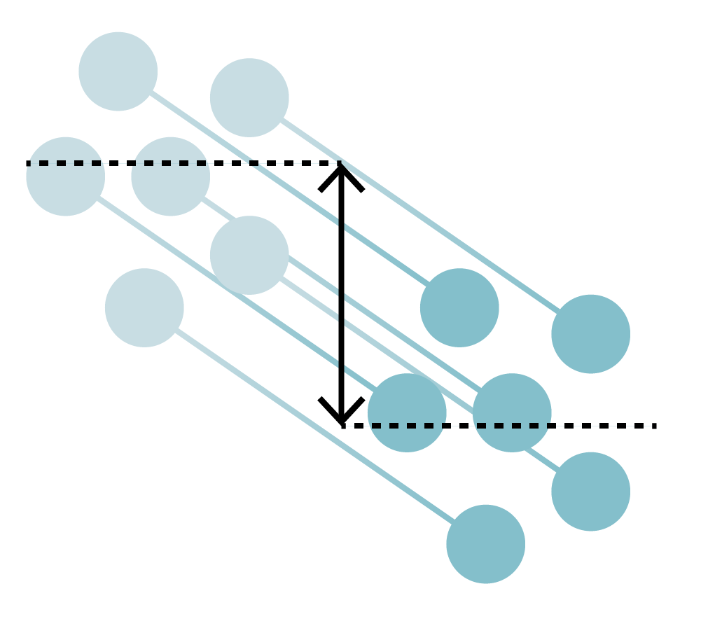

First we need to get data from every gameweek of 2023-24.

```r
# We need to get player details from every week
gws <- read_csv(url(paste0(github, "2023-24/gws/gw1.csv")))
for (i in 2:37){
  gw <- read_csv(url(paste0(github, "2023-24/gws/gw", i, ".csv")))
  gws <- rbind(gws, gw)
}
```

Then we filter for players that played at least 1 minute each week, and get the mean xGC for each team in each week. From this we can get the mean xGC for each team in each half of the season.

```r
# Get total xGC from all players for each team.
xGC_1_19 <- gws %>% filter(minutes>0, round<20) %>% group_by(round, team) %>% summarise(xGC=sum(expected_goals_conceded), mean_xGC=xGC/n()) %>% group_by(team) %>% summarise(mean_xGC = mean(mean_xGC))
xGC_20_37 <- gws %>% filter(minutes>0, round>19) %>% group_by(round, team) %>% summarise(xGC=sum(expected_goals_conceded), mean_xGC=xGC/n()) %>% group_by(team) %>% summarise(mean_xGC = mean(mean_xGC))

# Merge the two dataframes to visualise
xGC_1_19$gws <- 'GW1-19'
xGC_20_37$gws <- 'GW20-37'
xGC_merge <- rbind(xGC_1_19, xGC_20_37)
```

We can summarise this data using a boxplot.

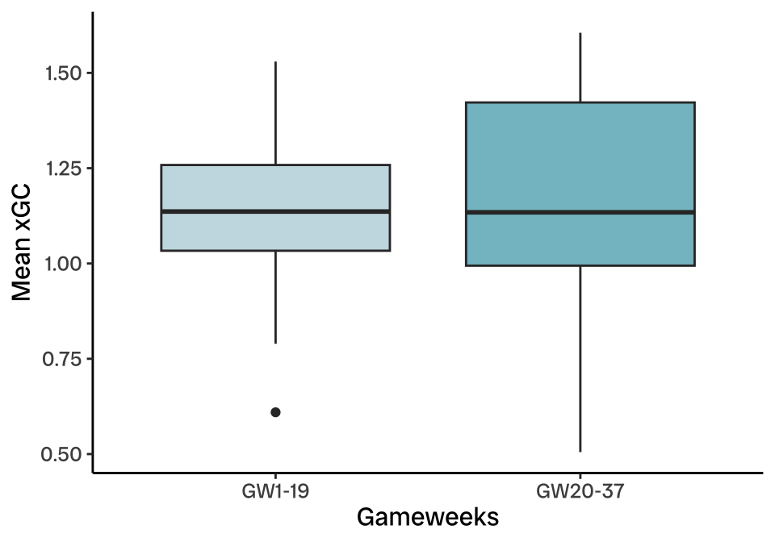

```r
# Set plot size
knitr::opts_chunk$set(fig.width=8, fig.height=3)

# Use ggplot to input values for x and y axis
ggplot(xGC_merge, aes(y=mean_xGC, x=gws)) +
  geom_boxplot(fill=c('#c8dde3', '#84bfcb')) +
  theme +
  labs(x='Gameweeks', y='Mean xGC')
```

We can also look at the data for each team. It is interesting to see that while some teams have a consistently low xGC (Arsenal), others appear to have much worse xGC in the second half of the season (Burnley, Aston Villa, Newcastle). But does this trend broadly persist across all the teams as a group?

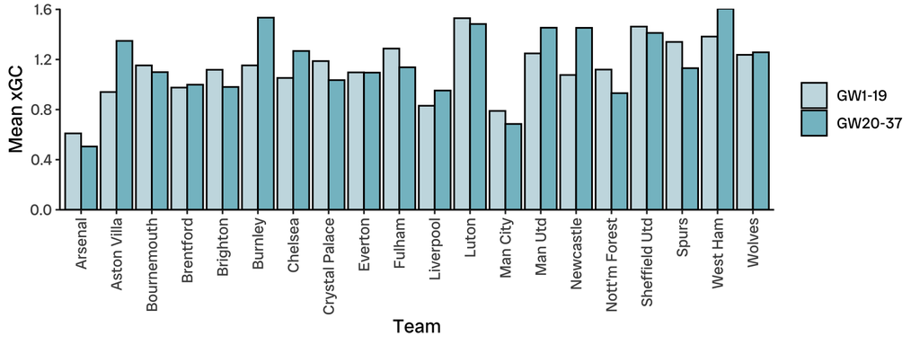

```r
# Set output size for plots
knitr::opts_chunk$set(fig.width=5, fig.height=3.5)

# Use ggplot to input values for x and y axis
ggplot(xGC_merge, aes(y=mean_xGC, x=team, fill=gws)) +
  geom_col(colour='black', position='dodge') +
  theme +
  theme(axis.text.x = element_text(angle = 90, vjust = 0.5, hjust=1)) +
  scale_fill_manual(values=c('#c8dde3','#84bfcb'))+
  scale_y_continuous(expand=c(0,0)) +
  labs(fill=NULL, x='Team', y='Mean xGC')
```

Before we do a t-test to check this hypothesis, we need to check that our data follows a normal distribution.

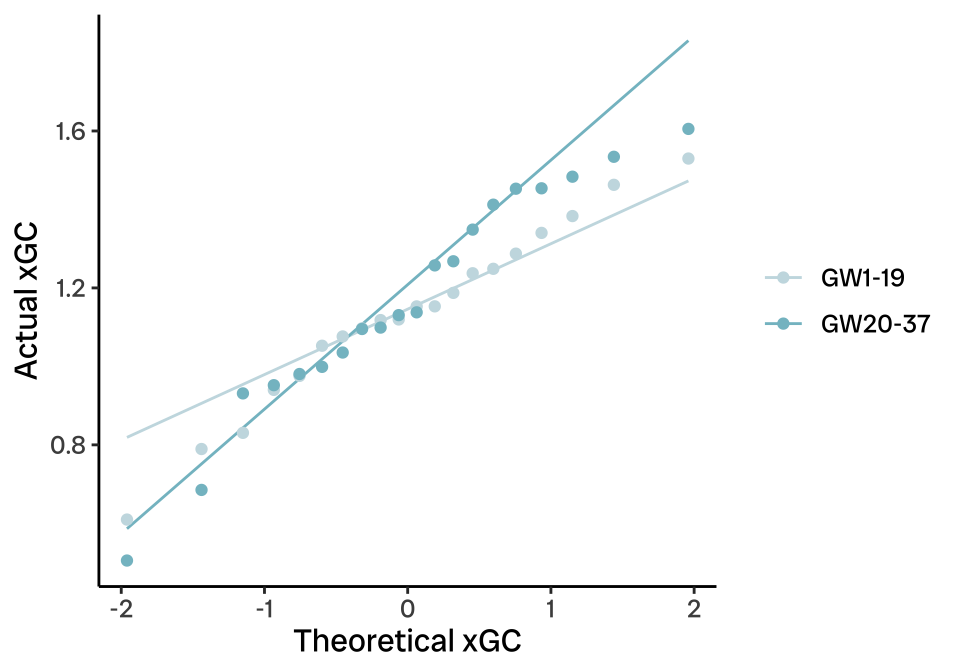

```r
# Does data follow normal distribution: QQ plot
ggplot(xGC_merge, aes(sample=(mean_xGC), colour=gws)) +
  geom_qq_line() +
  stat_qq() +
  theme_classic() +
  theme +
  labs(x='Theoretical xGC', y='Actual xGC', colour=NULL) +
  scale_colour_manual(values=c('#c8dde3', '#84bfcb'))
```

```r
# Does data follow normal distribution: Shapiro-Wilk
shapiro.test(xGC_1_19$mean_xGC)
```

```
##
##  Shapiro-Wilk normality test
##
## data:  xGC_1_19$mean_xGC
## W = 0.98056, p-value = 0.9411
```

```r
shapiro.test(xGC_20_37$mean_xGC)
```

```
##
##  Shapiro-Wilk normality test
##
## data:  xGC_20_37$mean_xGC
## W = 0.95841, p-value = 0.5126
```

From the QQ plot and Shapiro-Wilk tests we can conclude that the xGC data is approximately normally distributed for both sets of data. Now we can perform a paired t-test using the following equation.

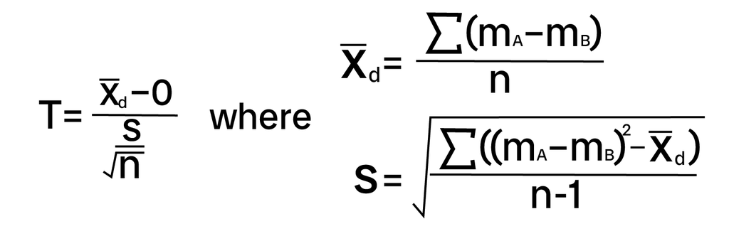

```r
# Get the difference between each pair
xGCdiff <- xGC_20_37$mean_xGC - xGC_1_19$mean_xGC

# Get the mean difference
xGCmeandiff <- sum(xGCdiff)/20

# Get the sd of the differences
xGCsigma <- sqrt(sum((xGCdiff - xGCmeandiff)**2)/19)

# Calculate the t-statistic
tStat <- xGCmeandiff/(xGCsigma/sqrt(20))
tStat
```

```
## [1] 0.8720348
```

We get a t-statistic of 0.872. We can use this value on a t-distribution to estimate the probability of getting this value or a more extreme value.

```r
# Calculate p-value
Tdistribution <- StudentsT(df = 19)
(1-cdf(Tdistribution, tStat))*100
```

```
## [1] 19.7038
```

```r
# Set output size for plots
knitr::opts_chunk$set(fig.width=8, fig.height=3.5)
```

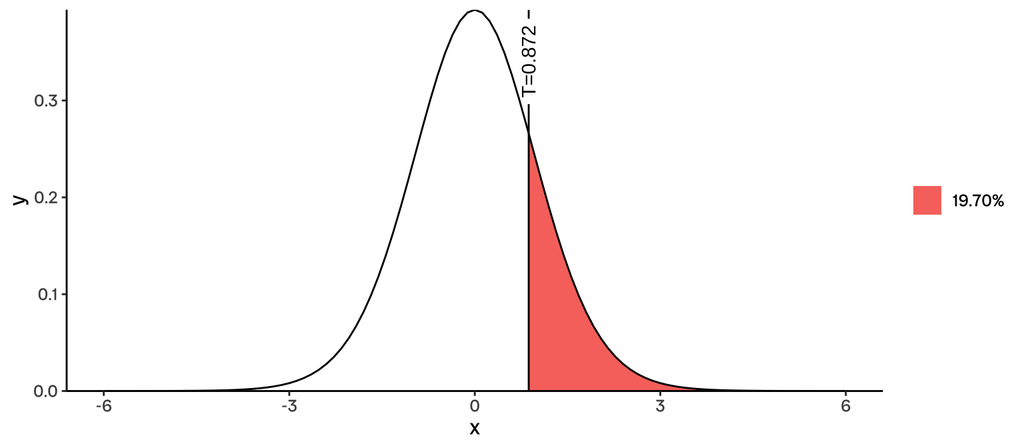

```r
# T-distribution plot
ggplot(data.frame(x = c(-6, 6)), aes(x = x)) +
  stat_function(fun = dt, args = list(df = 19), xlim=c(0.872, 5),
              geom = "area", aes(fill='19.70%')) +
  theme +
  labs(fill=NULL) +
  stat_function(fun = dt, args = list(df = 19)) +
  geom_textvline(label = 'T=0.872', hjust=0.95, xintercept=c(0.872), colour='black') +
  scale_y_continuous(expand=c(0,0))
```

The p-value is 19.70%, so we cannot reject the null hypothesis that there was a significant increase in xGC between the first and second halves of the season.

We can also use the t.test() function. The alternative hypothesis is ‘greater’, as we hypothesised that xGC in GW20-37 would be increased compared to GW1-19.

```r
t.test(xGC_20_37$mean_xGC, xGC_1_19$mean_xGC, paired = TRUE, alternative = "greater")
```

```
##
##  Paired t-test
##
## data:  xGC_20_37$mean_xGC and xGC_1_19$mean_xGC
## t = 0.87203, df = 19, p-value = 0.197
## alternative hypothesis: true mean difference is greater than 0
## 95 percent confidence interval:
##  -0.03809409         Inf
## sample estimates:
## mean difference
##      0.03875796
```